# HW 7

SDS348 Fall 2020

November 01, 2020

## Arun Krishnaraj - ak37738

**This homework is due Sunday Nov 1, 2020 at 11:59pm. Please submit as a pdf file on Canvas.**

*For all questions, include the R commands/functions that you used to find your answer. Answers without supporting code will not receive credit.*

> **Review of how to submit this assignment** All homework assignments will be completed using R Markdown. These `.Rmd` files consist of text/syntax (formatted using Markdown) alongside embedded R code. When you have completed the assignment (by adding R code inside codeblocks and supporting text outside of the codeblocks), create your document as follows:
> - Click the arrow next to the “Knit” button (above)
> - Choose “Knit to HTML” and wait; fix any errors if applicable
> - Go to Files pane and put checkmark next to the correct HTML file
> - Click on the blue gear icon (“More”) and click Export
> - Download the file and then upload to Canvas

## Question 1.1 (3 pts)

- Run the following code to generate some play data (variables x and y). Then, regress y on x with `lm(y~x)` and call summary() on the fitted model. Make a scatterplot (either base R or ggplot) to eyeball whether homoskedasticity is met (i.e., do the points fan out as you go up the x-axis?). Then run the Breuch-Pagan test `bptest()` to formally test this null hypothesis. If you reject the null hypothesis of homoskedasticity, redo the regression using heteroskedasticity robust standard errors. How does this change your t-statistics and p-values?

You will need the `lmtest` package and the `sandwich` package in order to do things like `bptest(fit)` and `coeftest(fit,vcov=vcovHC(fit))`; install them if you haven’t.

```r
set.seed(348)
x <- runif(55, 0, 1)
y <- 0.1 * rnorm(55, x, x)

model1 <- lm(y ~ x)
summary(model1)
```

```
##
## Call:
## lm(formula = y ~ x)
##
## Residuals:
##       Min        1Q    Median        3Q       Max
## -0.093907 -0.022208 -0.004808  0.024363  0.201202
##
## Coefficients:
##             Estimate Std. Error t value Pr(>|t|)
## (Intercept) 0.009742   0.013112   0.743   0.4608
## x           0.048460   0.023442   2.067   0.0436 *
## ---
## Signif. codes:  0 '***' 0.001 '**' 0.01 '*' 0.05 '.' 0.1 ' ' 1
##
## Residual standard error: 0.04878 on 53 degrees of freedom
## Multiple R-squared:  0.07461,    Adjusted R-squared:  0.05715
## F-statistic: 4.273 on 1 and 53 DF,  p-value: 0.04361
```

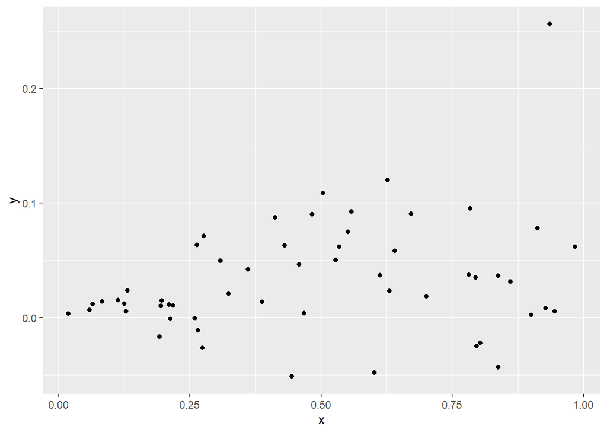

```r
library(ggplot2)
library(tidyverse)
qplot(x, y)
```

```r
library(lmtest)
library(sandwich)
bptest(model1)
```

```
##
##  studentized Breusch-Pagan test
##
## data:  model1
## BP = 6.118, df = 1, p-value = 0.01338
```

```r
coeftest(model1, vcov. = vcovHC(model1))
```

```
##
## t test of coefficients:
##
##              Estimate Std. Error t value Pr(>|t|)
## (Intercept) 0.0097416  0.0099737  0.9767  0.33314
## x           0.0484604  0.0282551  1.7151  0.09217 .
## ---
## Signif. codes:  0 '***' 0.001 '**' 0.01 '*' 0.05 '.' 0.1 ' ' 1
```

The scatterplot of points appears somewhat fanned out along the x-axis, indicating lack of homoskedasticity; the Breusch-Pagan test returns a p-value of 0.01338, indicating that we should reject the null hypothesis of homoskedasticity. The regression with robust standard errors produces a slightly smaller t statistic and larger p-value for the slope effect, and a larger t statistic and smaller p-value for the intercept.

## Question 1.2 (3 pts)

- Run the following code to generate more play data (new variables x and y). Then, regress y on x with `lm(y~x) and call summary. Make a scatterplot (either base R or ggplot) to eyeball whether homoskedasticity is met. Then, use the Breuch-Pagan test`bptest()` to formally test this null hypothesis. Regardless of the result, redo the regression using heteroskedasticity robust standard errors. How does this change your t-statistics and p-values? How does this change differ from before (both in direction and magnitude)?

```r
set.seed(348)
x <- runif(55, 0, 1)
y <- 0.1 * rnorm(55, x, 0.6)

model2 <- lm(y ~ x)
summary(model2)
```

```
##
## Call:
## lm(formula = y ~ x)
##
## Residuals:
##       Min        1Q    Median        3Q       Max
## -0.118236 -0.028612 -0.006171  0.038243  0.134009
##
## Coefficients:
##             Estimate Std. Error t value Pr(>|t|)
## (Intercept) 0.005426   0.014775   0.367   0.7149
## x           0.062463   0.026416   2.365   0.0217 *
## ---
## Signif. codes:  0 '***' 0.001 '**' 0.01 '*' 0.05 '.' 0.1 ' ' 1
##
## Residual standard error: 0.05496 on 53 degrees of freedom
## Multiple R-squared:  0.09543,    Adjusted R-squared:  0.07836
## F-statistic: 5.591 on 1 and 53 DF,  p-value: 0.02174
```

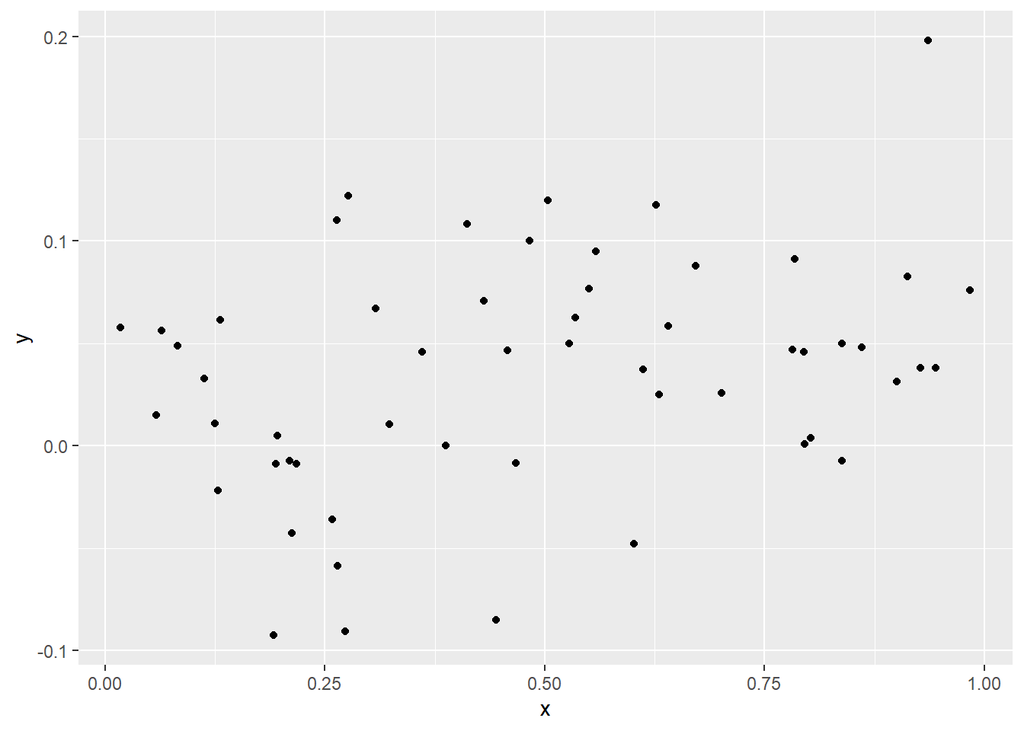

```r
qplot(x, y)
```

```r
bptest(model2)
```

```
##
##  studentized Breusch-Pagan test
##
## data:  model2
## BP = 0.19935, df = 1, p-value = 0.6552
```

```r
coeftest(model2, vcov. = vcovHC(model2))
```

```
##
## t test of coefficients:
##
##              Estimate Std. Error t value Pr(>|t|)
## (Intercept) 0.0054256  0.0149121  0.3638   0.7174
## x           0.0624628  0.0254661  2.4528   0.0175 *
## ---
## Signif. codes:  0 '***' 0.001 '**' 0.01 '*' 0.05 '.' 0.1 ' ' 1
```

The scatterplot and Breusch-Pagan test both indicate that the data is homoskedastic. The regression with robust standard errors has a larger t statistic and smaller p-value for the slope effect, and smaller t statistic and larger p-value for the intercept. The magnitude of the change is smaller than that in `1.1`, and the direction is opposite.

## Question 1.3 (3 pts)

Using `x` and `y` from 1.2, calculate the bootstrap standard error of the slope by resampling observations (i.e., rows) from your dataframe with replacement. Also, calculate the boostrap standard error of the slope by resampling residuals (from the model fit in 1.2, with replacement), adding them to the fitted values to get the new “data”, re-computing the regression coefficient, saving, and repeating. For each, use 5000 iterations. How do your results compare with the standard errors from question 1.2? Would you still reject the null hypothesis using these standard errors?

```r
set.seed(348)

m <- as.data.frame(cbind(x, y))

library(dplyr)

samp_dist <- replicate(5000, {
    boot_data <- sample_frac(m, replace = T)
    fit <- lm(y ~ x, data = boot_data)
    coef(fit)
})

samp_dist %>% t %>% as.data.frame %>% summarise_all(sd)
```

```
##   (Intercept)          x
## 1  0.01466772 0.02484079
```

```r
resids <- model2$residuals
fitted <- model2$fitted.values

resid_resamp <- replicate(5000, {
    new_resids <- sample(resids, replace = TRUE)
    m$new_y <- fitted + new_resids
    fit <- lm(new_y ~ x, data = m)
    coef(fit)
})

resid_resamp %>% t %>% as.data.frame %>% summarise_all(sd)
```

```
##   (Intercept)          x
## 1  0.01460879 0.02614435
```

## Question 2.1 (3 pts)

Using the `msleep` data (in ggplot2), regress `sleep_rem` on the interaction of `brainwt` and `vore`. Interpret the intercept in context. Interpret the coefficient `brainwt` in context. Interpret the coefficient for `voreinsecti` in context. Interpret the coefficient for `brainwt:voreinsecti` in context (Ignore significance, etc.)

```r
lm(sleep_rem ~ brainwt * vore, data = msleep) %>% summary
```

```
##
## Call:
## lm(formula = sleep_rem ~ brainwt * vore, data = msleep)
##
## Residuals:
##      Min       1Q   Median       3Q      Max
## -1.32515 -0.65057 -0.09685  0.43587  2.80300
##
## Coefficients:
##                     Estimate Std. Error t value Pr(>|t|)
## (Intercept)          2.68511    0.48162   5.575  2.8e-06 ***
## brainwt             -3.42607    3.49182  -0.981  0.33324
## voreherbi           -1.20881    0.55723  -2.169  0.03693 *
## voreinsecti         -0.04121    0.72892  -0.057  0.95524
## voreomni            -0.58505    0.54330  -1.077  0.28891
## brainwt:voreherbi    1.42876    3.69597   0.387  0.70141
## brainwt:voreinsecti 46.01707   13.95225   3.298  0.00224 **
## brainwt:voreomni     2.94134    3.56621   0.825  0.41508
## ---
## Signif. codes:  0 '***' 0.001 '**' 0.01 '*' 0.05 '.' 0.1 ' ' 1
##
## Residual standard error: 0.9408 on 35 degrees of freedom
##   (40 observations deleted due to missingness)
## Multiple R-squared:  0.5087, Adjusted R-squared:  0.4104
## F-statistic: 5.176 on 7 and 35 DF,  p-value: 0.0004084
```

Brain weight is weakly associated with REM sleep for carnivores: for every 1-unit increase in brain weight, predicted REM sleep decreases by 3.42 hours for this group. Insectivores with zero brain weight have predicted REM sleep that is 0.04 hours lower than carnivores with zero brain weight. The slope of brain weight on hours of REM sleep for insectivores is 46.017 greater than for carnivores.

## Question 2.2 (2 pts)

Rerun the same regression as above, but center the `brainwt` variable first by subtracting the mean (use na.rm=T). Which coefficients that you interpreted in 2a (above) changed? Why? Reinterpret any coefficient from part 2.1 that changed. (Ignore significance, etc.)

```r
msleep$brainwt_c <- msleep$brainwt - mean(msleep$brainwt,
    na.rm = T)

lm(sleep_rem ~ brainwt_c * vore, data = msleep) %>%
    summary()
```

```
##
## Call:
## lm(formula = sleep_rem ~ brainwt_c * vore, data = msleep)
##
## Residuals:
##      Min       1Q   Median       3Q      Max
## -1.32515 -0.65057 -0.09685  0.43587  2.80300
##
## Coefficients:
##                       Estimate Std. Error t value Pr(>|t|)
## (Intercept)             1.7204     0.7920   2.172  0.03670 *
## brainwt_c              -3.4261     3.4918  -0.981  0.33324
## voreherbi              -0.8065     0.8475  -0.952  0.34780
## voreinsecti            12.9163     3.6426   3.546  0.00113 **
## voreomni                0.2432     0.8301   0.293  0.77129
## brainwt_c:voreherbi     1.4288     3.6960   0.387  0.70141
## brainwt_c:voreinsecti  46.0171    13.9522   3.298  0.00224 **
## brainwt_c:voreomni      2.9413     3.5662   0.825  0.41508
## ---
## Signif. codes:  0 '***' 0.001 '**' 0.01 '*' 0.05 '.' 0.1 ' ' 1
##
## Residual standard error: 0.9408 on 35 degrees of freedom
##   (40 observations deleted due to missingness)
## Multiple R-squared:  0.5087, Adjusted R-squared:  0.4104
## F-statistic: 5.176 on 7 and 35 DF,  p-value: 0.0004084
```

The `voreinsecti` coefficient changed from -0.04 to 12.91; this occurs due to the difference in mean brain weight between `vore` groups, and the unreasonable interpretation of zero brain weight. Besides this change, there is a minor change in the `voreomni` coefficient: omnivores with mean brain weight have predicted REM sleep that is 0.24 hours higher than carnivores with mean brain weight. Herbivores with mean brain weight have predicted REM sleep that is 0.81 hours lower than carnivores with mean brain weight.

## Question 2.3 (2 pts)

Remove NA from `vore` only (i.e., use filter rather than na.omit) and make a plot of `rem_sleep` by `brainwt` colored/grouped by vore, using `geom_smooth(method="lm")` to visualize this regression. What is the mean value of brainwt? Using the plot, Does it make sense to extrapolate to this value for the `voreinsecti` coefficient (think about your interpretation of this coefficient in 2.2)?

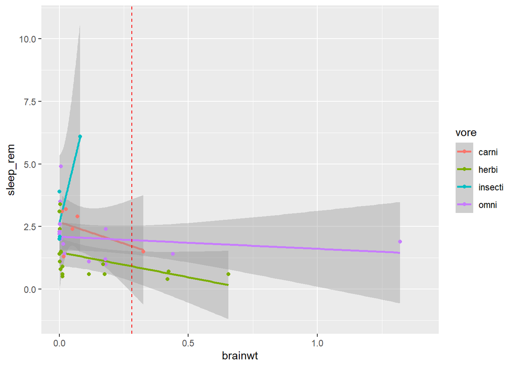

```r
msleep %>% filter(!is.na(vore)) %>% ggplot(aes(x = brainwt,
    y = sleep_rem, group = vore)) + geom_smooth(aes(color = vore),
    method = "lm") + geom_point(aes(color = vore)) +
    geom_vline(xintercept = mean(msleep$brainwt, na.rm = T),
        col = "red", lty = 2) + xlim(0, 1.4)
```

Brain weight has a mean value of .28 kilograms; it would not make sense to extrapolate this for the `voreinsecti` coefficient, since we can see that all insectivores have significantly less than average brain weight. It’s not sensible to interpret the `voreinsecti` coefficient as the difference in REM sleep compared to the carnivores for zero brain weight, when the distribution of brainweight in each group is clearly different.

## Question 2.4 (2 pts)

Regression makes no assumptions about the distribution of the predictors, and taking the log will fix the issue observed in 2.3. Take the natural log of brainwt, then center it (don’t forget `na.rm=T`), and then rerun the regression model with this brainwt variable instead (note that you can’t just take the log of the centered variable). Use heteroskedasticity robust standard errors `coeftest(fit, vcov=vcovHC(fit))`. Interpret the one significant effect and, finally, discuss significance and your decision with respect to the null hypothesis

```r
msleep$log_brainwt_c <- log(msleep$brainwt) - mean(log(msleep$brainwt),
    na.rm = T)

model3 <- lm(sleep_rem ~ log_brainwt_c * vore, data = msleep)
coeftest(model3, vcov. = vcovHC(model3))
```

```
##
## t test of coefficients:
##
##                            Estimate Std. Error t value  Pr(>|t|)
## (Intercept)                2.640154   0.585951  4.5058 7.068e-05 ***
## log_brainwt_c             -0.268484   0.450970 -0.5953    0.5554
## voreherbi                 -1.408729   0.621094 -2.2681    0.0296 *
## voreinsecti                2.259368   3.941791  0.5732    0.5702
## voreomni                  -0.635335   0.633588 -1.0028    0.3229
## log_brainwt_c:voreherbi    0.034044   0.458258  0.0743    0.9412
## log_brainwt_c:voreinsecti  0.853802   1.145566  0.7453    0.4611
## log_brainwt_c:voreomni     0.157875   0.458268  0.3445    0.7325
## ---
## Signif. codes:  0 '***' 0.001 '**' 0.01 '*' 0.05 '.' 0.1 ' ' 1
```

## Question 2.5 (2 pts)

Make a new plot just like 2.3 (remove NAs from `vore` manually), but this time use the log of `brainwt` on the x-axis and include `geom_smooth(method="lm")` to visualize the regression from 2.4. Where can you see the significant effect on the plot (describe in words)?

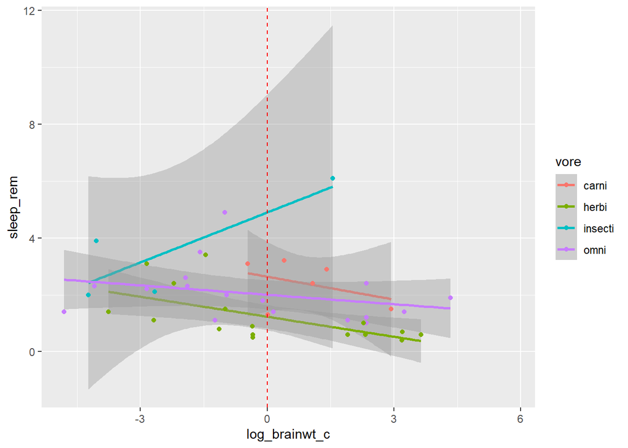

```r
msleep %>% filter(!is.na(vore)) %>% ggplot(aes(y = sleep_rem,
    x = log_brainwt_c, group = vore)) + geom_smooth(aes(color = vore),
    method = "lm") + geom_point(aes(color = vore)) +
    geom_vline(xintercept = mean(msleep$log_brainwt_c,
        na.rm = T), col = "red", lty = 2)
```

[output not shown]

[output not shown]